# lobster-project

Anna Calle

11/12/2018

```
## # A tibble: 30 x 4
## # Groups:   SITE [?]
##    SITE   YEAR abundance    sd
##    <chr> <int>     <int> <dbl>
##  1 AQUE   2012        38 0.573
##  2 AQUE   2013        32 0.726
##  3 AQUE   2014       100 1.70
##  4 AQUE   2015        83 1.06
##  5 AQUE   2016        48 1.10
##  6 AQUE   2017        67 1.30
##  7 CARP   2012        78 0.662
##  8 CARP   2013        93 0.893
##  9 CARP   2014        78 0.618
## 10 CARP   2015        90 0.779
## # ... with 20 more rows
```

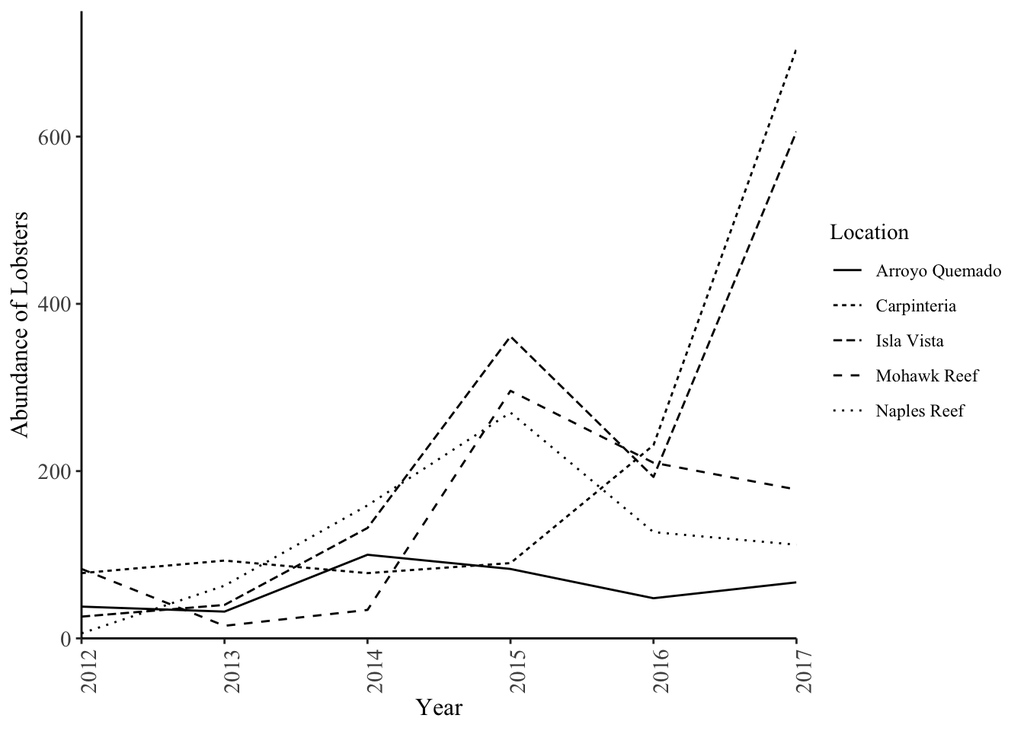

| Year | Arroyo Quemado | Carpinteria | Isla Vista | Mohawk Reef | Naples Reef |
| --- | --- | --- | --- | --- | --- |
| 2012 | 38 | 78 | 26 | 83 | 6 |
| 2013 | 32 | 93 | 40 | 15 | 63 |
| 2014 | 100 | 78 | 132 | 34 | 159 |
| 2015 | 83 | 90 | 361 | 296 | 270 |
| 2016 | 48 | 231 | 193 | 210 | 127 |
| 2017 | 67 | 705 | 606 | 178 | 112 |

**Figure 1. Abundance of Lobsters in Santa Barbara Channel (2012-2017).** Lobster counts measured at Long Term Ecological Research Sites (LTERS) in the Santa Barbara Channel: Arroyo Quemado (AQUE), Naples Reef (NAPL), Mohawk Reef (MOHK), Isla Vista (IVEE), Carpinteria (CARP) from 2012 to 2017.

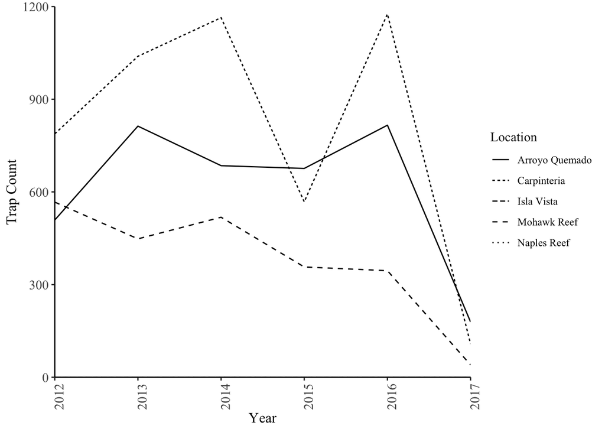

**Figure 2. Fishing Pressure in Santa Barbara Channel (2012-2017).** Trap Buoy counts measured at Long Term Ecological Research Sites (LTERS) in the Santa Barbara Channel: Arroyo Quemado (AQUE), Naples Reef (NAPL), Mohawk Reef (MOHK), Isla Vista (IVEE), Carpinteria (CARP) from 2012 to 2017. No trap buoys were measured for Isla Vista or Naples Reef.